Alaska Department of Health and Social Services Weekly COVID-19 and Influenva Update

March 27 – April 2, 2022

## COVID-19

### COVID-19 Case Trends

| Borough/Census Area | Case Rate Per 100K | Cases_Last_7_Days | Case_Trend |
| --- | --- | --- | --- |
| Alaska | 173.69 | 1,266 | NA |
| Aleutians East Borough | 205.13 | 6 | NA |
| Aleutians West Census Area | ** | 3 | NA |
| Anchorage Municipality | 191.72 | 554 | NA |
| Bethel Census Area | 296.62 | 53 | NA |
| Bristol Bay plus Lake and Peninsula | 413.22 | 10 | NA |
| Chugach Census Area | 133.31 | 9 | NA |
| Copper River Census Area | ** | 2 | NA |
| Denali Borough | ** | 0 | NA |
| Dillingham Census Area | 879.95 | 42 | NA |

[output cut: 19 more lines]

##### *Rates based on <20 observations are statistically unreliable and should be used with caution.

##### **Rates based on <6 observations are not reported.

##### Alert levels are based on case report date. The case rates in the Kusilvak and Bethel Census Areas are artificially elevated this past week due to processing of delayed reports.

### COVID-19 and Hospital Capacity

- Hospital capacity remains limited. Large numbers of patients overall (not necessarily with COVID-19 or other respiratory viruses) relative to the number of available staff continue to create capacity challenges across the state, with some areas more affected than others.
- Patient Care Strategies for Scare Resource Situations are currently not being utilized by any facility in Alaska. However, given the continued limited capacity of some facilities, the Crisis Care Committee continues to meet to monitor the situation and remains available to assist facilities and DHSS should the need arise.
- As of March 14, 2022, there were 38 persons with COVID-19 in Alaska hospitals, accounting for 3.1% of all hospitalized persons. Visit the Hospital Dashboard for more data.

### COVID-19 and Vaccination

- 71.2% of Alaska residents aged ≥5 years have received at least one dose of a COVID-19 vaccine. Among those who completed the primary vaccine series, 50.2% of Alaska residents ≥18 years have received their booster. Learn more about COVID-19 vaccination coverage in Alaska on the Vaccine Dashboard. Learn more about COVID-19 vaccines.
- Vaccines help protect against infection and against severe disease, especially when a person is up to date on vaccinations. During the 4-week period from February 6, 2022–March 5, 2022, unvaccinated Alaskans were 7.3 times more likely to be hospitalized due to COVID-19 than Alaskans who are up to date on COVID-19 vaccination (i.e., completed the primary series and received a booster dose, if eligible) and 2.9 times more likely to be hospitalized due to COVID-19 than Alaskans who completed the primary vaccination series but are not up to date. These estimates are lagged by one week to partially account for the time it takes to document hospitalizations. (See the monthly report for more data and analysis through January.)

- Among Alaska residents aged ≥5 years from January 16, 2021–March 12, 2022, 69,054 cases were documented in persons who had completed the primary series and were considered fully vaccinated. Among those vaccine-breakthrough cases, 515 hospitalizations and 180 deaths due to COVID-19 have been recorded. During that time, 98,276 cases have been documented in unvaccinated Alaskans aged ≥5 years, leading to 1,836 hospitalizations and 642 deaths. All data are preliminary and subject to change.
- During the Omicron wave, the incidence of COVID-19 cases in vaccinated persons has become more similar to the incidence in unvaccinated persons. This trend likely reflects multiple factors which may include: immunity wanes over time, cases in vaccinated persons may be more likely to be detected than cases in unvaccinated persons, and there may be increased infection-induced immunity especially among unvaccinated persons.

## Influenza (“Flu”)

- Reported influenza cases began increasing in Alaska in mid-December. The number of reported cases the week of March 27–April 2 remained similar to the number reported the previous week.
- Right now, most influenza in Alaska is caused by influenza A. 24% of Alaskans aged ≥10 years have been vaccinated against seasonal influenza. It is not too late to get vaccinated against influenza.
- Learn more in the weekly Alaska Influenza Snapshot.

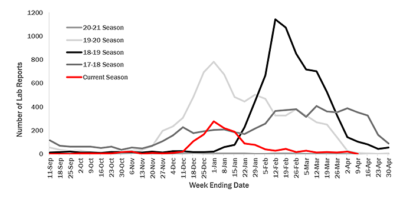

##### Positive influenza lab reports in Alaska by week of specimen collection for the 2017-2018 influenza season through present. The current season through April 2, 2022 is shown in red.

## Emergency Department Visits

### Visits with COVID-like or Influenza-like Illness

- Syndromic surveillance consists of analyzing data on symptoms and diagnoses among patients visiting emergency departments in Alaska. The main goal is to identify trends. Unlike case-based surveillance, syndromic surveillance does not depend on laboratory testing.
- Influenza-like illness (ILI) is defined as having a fever and at least one other symptom, such cough or sore throat. Patients with a diagnosis of influenza are also included, regardless of symptoms.
- COVID-like illness (CLI) encompasses a broader array of respiratory and other symptoms than influenza-like illness. This category also includes any patient with a diagnosis of COVID-19, regardless of symptoms.
- Patients with a diagnosis of COVID-19 are excluded from the ILI category and, likewise, patients with a diagnosis of influenza are excluded from the CLI category. But a patient without a diagnosis for either could be included in both the CLI and ILI categories. CLI and ILI may be caused by respiratory viruses other than SARS-CoV-2 and influenza virus.
- As the Delta variant wave waned in Alaska in late October and November 2021, the percentage of emergency department patients with CLI declined. However, it increased in mid-December, reaching its peak in mid-January. Now, it is at a level lower than that observed in December before the Omicron wave. The percentage of emergency department patients with CLI the week of March 27–April 2 remained similar to the percentage recorded the prior week.
- ILI levels increased in December but have since decreased from the late-December peak, remaining steady over the last few weeks.

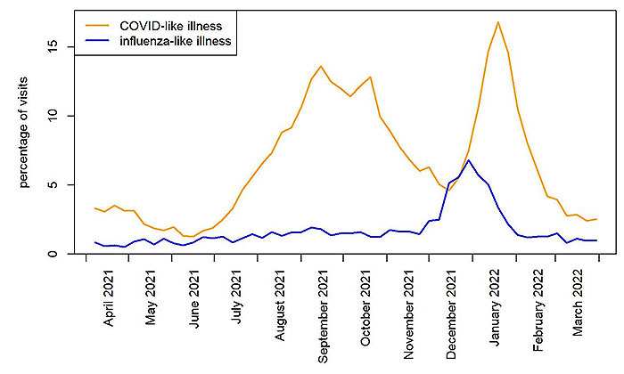

## New Updates

### Updates to protect yourself and your family

- Vaccine boosters: Everyone 12 or older should get a COVID-19 vaccine booster if it’s been five months since receiving the Pfizer or Moderna vaccines or two months since receiving the Johnson & Johnson vaccine. People over the age of 50 and some immunocompromised individuals may receive a second mRNA booster (Pfizer or Moderna) four months after their first booster dose. Additionally, people who have received the Johnson & Johnson vaccine for both their primary dose and booster dose may receive a second booster dose using an mRNA vaccine. Pfizer or Moderna vaccine boosters are preferred. Individuals aged 12-17 can receive a Pfizer booster only.
- DHSS Community Case Rates: To complement the CDC’s Community Levels tool, DHSS has introduced a new Community Case Rates tool. Both tools can help individuals, organizations, and communities make decisions about prevention measures. The Alert Levels on the dashboard have been retired and replaced by Community Case Rates.
- Ask a health care provider about treatment: If you test positive and you’re at increased risk for severe COVID, ask a health care provider about treatment options. Treatments can reduce the risk of hospitalization and they work best when given soon after symptoms start. Learn more about COVID-19 treatments and where you can find COVID-19 treatments.

## Information and Resources

- The State of Alaska COVID-19 vaccines update page
- The State of Alaska COVID-19 information page provides more information about the virus and how individuals and businesses can protect themselves and others from transmission.
- The DHSS Business and Employer Toolkits page has communications resources for any organization that wants to keep workers, partners, clients, and customers informed about COVID-19.
- DHSS COVID-19 Communication Toolkit provides PSAs, flyers, and social media graphics. ** Learn more about the importance of physical activity, highlighted by our Play Every Day and our Healthy You 2022 campaigns: Play Every Day.
- Subscribe to the DHSS Insights blog for behind-the-scenes news about Alaska’s COVID-19 response and other efforts to protect the health and well-being of Alaskans.
- DHSS offers free presentations upon request to groups about COVID-19, the vaccines, COVID-19 prevention, or other health topics upon request. Learn more or request a presentation on our Speaker’s Bureau web page.
- For the most up-to-date case information, see the Alaska COVID-19 Information Hub dashboard: data.coronavirus.alaska.gov. All dashboard data are updated Wednesdays (except holidays).
- For DHSS media inquiries, please contact clinton.bennett@alaska.gov